# **AIR QUALITY PREDICTION**

## **Problem Statement:**

We are given a dataset of AQI of India between 2015 to 2020. The task is to built a model that can predict accurately the AQI based on the independent features available in the dataset.

## **About Dataset**

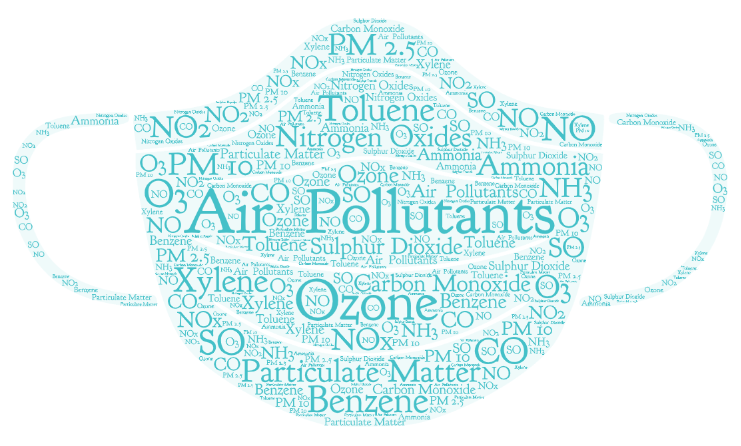

### **Major Air Pollutants**

**Particulate matter**

Particulate matter is a mix of solids and liquids, including carbon, complex organic chemicals, sulphates, nitrates, mineral dust,and water suspended in the air. Based on their size in micrometers they classified as PM 2.5 and PM 10.

**Nitrogen Oxides**

Nitrogen oxides are composed of grouping of nitrogen and oxygen ,classified as NOx gases,nitric oxide(NO) and nitrogen dioxide(NO2) are most common .they were mainly produced as the result of fossil fuel combustion .

**Ammonia**

Ammonia is the most abundant alkaline gas in the atmosphere. NH3 plays a significant role in the formation of atmospheric particulate matter. Ammonia is considered as the by-product of agriculture and industry

**Sulphur Dioxide**

Sulfur dioxide is a colourless gas with a strong odour, it is formed when fuel containing sulphur, such as coal and oil, is burned, creating air pollution. It affects the environment when they react with substances in the atmosphere to form acid rain.

**Ozone**

Ground level ozone is a colourless and highly irritating gas that forms just above the earth's surface.

**Carbon Monoxide**

Incomplete combustion of carbon containing fuels produces carbon monoxide. Carbon monoxide is a colourless, highly poisonous gas.

**Benzene**

The benzene in indoor comes from product that contain benzene such as glues, paints , furniture wax , and detergents.

**Toluene**

Motor vehicle and industrial emissions are the major sources of pollutants.

**Xylene**

Motor vehicle emissions are the predominant source of xylene in the urban air environment.

## **Importing Libraries and Data**

```python
# importing important libraries
import pandas as pd
import numpy as np
import matplotlib.pyplot as plt
```

```python
df_city_day = pd.read_csv('/content/city_day.csv')
```

```python
df_city_hour = pd.read_csv('/content/city_hour.csv')
```

```python
df_city_day.head()
```

|  | City | Date | PM2.5 | PM10 | NO | NO2 | NOx | NH3 | CO | SO2 | O3 | Benzene | Toluene | Xylene | AQI | AQI_Bucket |
| --- | --- | --- | --- | --- | --- | --- | --- | --- | --- | --- | --- | --- | --- | --- | --- | --- |
| 0 | Ahmedabad | 2015-01-01 | NaN | NaN | 0.92 | 18.22 | 17.15 | NaN | 0.92 | 27.64 | 133.36 | 0.00 | 0.02 | 0.00 | NaN | NaN |
| 1 | Ahmedabad | 2015-01-02 | NaN | NaN | 0.97 | 15.69 | 16.46 | NaN | 0.97 | 24.55 | 34.06 | 3.68 | 5.50 | 3.77 | NaN | NaN |
| 2 | Ahmedabad | 2015-01-03 | NaN | NaN | 17.40 | 19.30 | 29.70 | NaN | 17.40 | 29.07 | 30.70 | 6.80 | 16.40 | 2.25 | NaN | NaN |
| 3 | Ahmedabad | 2015-01-04 | NaN | NaN | 1.70 | 18.48 | 17.97 | NaN | 1.70 | 18.59 | 36.08 | 4.43 | 10.14 | 1.00 | NaN | NaN |
| 4 | Ahmedabad | 2015-01-05 | NaN | NaN | 22.10 | 21.42 | 37.76 | NaN | 22.10 | 39.33 | 39.31 | 7.01 | 18.89 | 2.78 | NaN | NaN |

```python
df_city_hour.head()
```

|  | City | Datetime | PM2.5 | PM10 | NO | NO2 | NOx | NH3 | CO | SO2 | O3 | Benzene | Toluene | Xylene | AQI | AQI_Bucket |
| --- | --- | --- | --- | --- | --- | --- | --- | --- | --- | --- | --- | --- | --- | --- | --- | --- |
| 0 | Ahmedabad | 2015-01-01 01:00:00 | NaN | NaN | 1.00 | 40.01 | 36.37 | NaN | 1.00 | 122.07 | NaN | 0.0 | 0.0 | 0.0 | NaN | NaN |
| 1 | Ahmedabad | 2015-01-01 02:00:00 | NaN | NaN | 0.02 | 27.75 | 19.73 | NaN | 0.02 | 85.90 | NaN | 0.0 | 0.0 | 0.0 | NaN | NaN |
| 2 | Ahmedabad | 2015-01-01 03:00:00 | NaN | NaN | 0.08 | 19.32 | 11.08 | NaN | 0.08 | 52.83 | NaN | 0.0 | 0.0 | 0.0 | NaN | NaN |
| 3 | Ahmedabad | 2015-01-01 04:00:00 | NaN | NaN | 0.30 | 16.45 | 9.20 | NaN | 0.30 | 39.53 | 153.58 | 0.0 | 0.0 | 0.0 | NaN | NaN |
| 4 | Ahmedabad | 2015-01-01 05:00:00 | NaN | NaN | 0.12 | 14.90 | 7.85 | NaN | 0.12 | 32.63 | NaN | 0.0 | 0.0 | 0.0 | NaN | NaN |

## **Understanding the data**

```python
df_city_day.shape
```

```
(29531, 16)
```

```python
df_city_day.describe()
```

|  | PM2.5 | PM10 | NO | NO2 | NOx | NH3 | CO | SO2 | O3 | Benzene | Toluene | Xylene | AQI |
| --- | --- | --- | --- | --- | --- | --- | --- | --- | --- | --- | --- | --- | --- |
| count | 24933.000000 | 18391.000000 | 25949.000000 | 25946.000000 | 25346.000000 | 19203.000000 | 27472.000000 | 25677.000000 | 25509.000000 | 23908.000000 | 21490.000000 | 11422.000000 | 24850.000000 |
| mean | 67.450578 | 118.127103 | 17.574730 | 28.560659 | 32.309123 | 23.483476 | 2.248598 | 14.531977 | 34.491430 | 3.280840 | 8.700972 | 3.070128 | 166.463581 |
| std | 64.661449 | 90.605110 | 22.785846 | 24.474746 | 31.646011 | 25.684275 | 6.962884 | 18.133775 | 21.694928 | 15.811136 | 19.969164 | 6.323247 | 140.696585 |
| min | 0.040000 | 0.010000 | 0.020000 | 0.010000 | 0.000000 | 0.010000 | 0.000000 | 0.010000 | 0.010000 | 0.000000 | 0.000000 | 0.000000 | 13.000000 |
| 25% | 28.820000 | 56.255000 | 5.630000 | 11.750000 | 12.820000 | 8.580000 | 0.510000 | 5.670000 | 18.860000 | 0.120000 | 0.600000 | 0.140000 | 81.000000 |
| 50% | 48.570000 | 95.680000 | 9.890000 | 21.690000 | 23.520000 | 15.850000 | 0.890000 | 9.160000 | 30.840000 | 1.070000 | 2.970000 | 0.980000 | 118.000000 |
| 75% | 80.590000 | 149.745000 | 19.950000 | 37.620000 | 40.127500 | 30.020000 | 1.450000 | 15.220000 | 45.570000 | 3.080000 | 9.150000 | 3.350000 | 208.000000 |
| max | 949.990000 | 1000.000000 | 390.680000 | 362.210000 | 467.630000 | 352.890000 | 175.810000 | 193.860000 | 257.730000 | 455.030000 | 454.850000 | 170.370000 | 2049.000000 |

```python
#summary of data
df_city_day.info()
```

```
<class 'pandas.core.frame.DataFrame'>
RangeIndex: 29531 entries, 0 to 29530
Data columns (total 16 columns):
 #   Column      Non-Null Count  Dtype
---  ------      --------------  -----
 0   City        29531 non-null  object
 1   Date        29531 non-null  object
 2   PM2.5       24933 non-null  float64
 3   PM10        18391 non-null  float64
 4   NO          25949 non-null  float64
 5   NO2         25946 non-null  float64
 6   NOx         25346 non-null  float64
 7   NH3         19203 non-null  float64
 8   CO          27472 non-null  float64
 9   SO2         25677 non-null  float64
 10  O3          25509 non-null  float64
 11  Benzene     23908 non-null  float64
 12  Toluene     21490 non-null  float64
 13  Xylene      11422 non-null  float64
 14  AQI         24850 non-null  float64
 15  AQI_Bucket  24850 non-null  object
dtypes: float64(13), object(3)
memory usage: 3.6+ MB
```

Since our Date column is of type object, we need to convert it to Datetime format.

```python
#converting Date to Datetime format
df_city_day['Date']=pd.to_datetime(df_city_day['Date'])
```

**Check for Null values**

```python
#checking null values
df_city_day.isna().sum()
```

```
City              0
Date              0
PM2.5          4598
PM10          11140
NO             3582
NO2            3585
NOx            4185
NH3           10328
CO             2059
SO2            3854
O3             4022
Benzene        5623
Toluene        8041
Xylene        18109
AQI            4681
AQI_Bucket     4681
dtype: int64
```

```python
# Replacing Null values
null_col = ['PM2.5',	'PM10',	'NO',	'NO2',	'NOx',	'NH3',	'CO',	'SO2',	'O3',	'Benzene',	'Toluene',	'Xylene',	'AQI']
for col in null_col:
  df_city_day[col] = df_city_day[col].fillna(df_city_day[col].median())
```

```python
df_city_day.isna().sum()
```

```
City             0
Date             0
PM2.5            0
PM10             0
NO               0
NO2              0
NOx              0
NH3              0
CO               0
SO2              0
O3               0
Benzene          0
Toluene          0
Xylene           0
AQI              0
AQI_Bucket    4681
dtype: int64
```

```python
df_city_day.head()
```

|  | City | Date | PM2.5 | PM10 | NO | NO2 | NOx | NH3 | CO | SO2 | O3 | Benzene | Toluene | Xylene | AQI | AQI_Bucket |
| --- | --- | --- | --- | --- | --- | --- | --- | --- | --- | --- | --- | --- | --- | --- | --- | --- |
| 0 | Ahmedabad | 2015-01-01 | 48.57 | 95.68 | 0.92 | 18.22 | 17.15 | 15.85 | 0.92 | 27.64 | 133.36 | 0.00 | 0.02 | 0.00 | 118.0 | NaN |
| 1 | Ahmedabad | 2015-01-02 | 48.57 | 95.68 | 0.97 | 15.69 | 16.46 | 15.85 | 0.97 | 24.55 | 34.06 | 3.68 | 5.50 | 3.77 | 118.0 | NaN |
| 2 | Ahmedabad | 2015-01-03 | 48.57 | 95.68 | 17.40 | 19.30 | 29.70 | 15.85 | 17.40 | 29.07 | 30.70 | 6.80 | 16.40 | 2.25 | 118.0 | NaN |
| 3 | Ahmedabad | 2015-01-04 | 48.57 | 95.68 | 1.70 | 18.48 | 17.97 | 15.85 | 1.70 | 18.59 | 36.08 | 4.43 | 10.14 | 1.00 | 118.0 | NaN |
| 4 | Ahmedabad | 2015-01-05 | 48.57 | 95.68 | 22.10 | 21.42 | 37.76 | 15.85 | 22.10 | 39.33 | 39.31 | 7.01 | 18.89 | 2.78 | 118.0 | NaN |

**Still we have NaN values for AQI_Bucket**

```python
# Unique count of AQI_Bucket
df_city_day['AQI_Bucket'].value_counts()
```

```
Moderate        8829
Satisfactory    8224
Poor            2781
Very Poor       2337
Good            1341
Severe          1338
Name: AQI_Bucket, dtype: int64
```

```python
df_city_day.groupby('AQI_Bucket')['AQI'].mean()
```

```
AQI_Bucket
Good             40.268456
Moderate        136.671877
Poor            245.663430
Satisfactory     76.765686
Severe          567.886398
Very Poor       343.004279
Name: AQI, dtype: float64
```

Taking the mean AQI as a reference from above table, we will replace the NaN values of AQI_Bucket.

```python
#Replacing Null values of AQI_Bucket using a condition
d1 =  df_city_day[df_city_day.AQI<=50 ].AQI_Bucket.fillna('Good')
d2 =  df_city_day[(df_city_day.AQI>50) & (df_city_day.AQI<=100)].AQI_Bucket.fillna('Satisfactory')
d3 =  df_city_day[(df_city_day.AQI>100) & (df_city_day.AQI<=180)].AQI_Bucket.fillna('Moderate')
d4 =  df_city_day[(df_city_day.AQI>180) & (df_city_day.AQI<=300)].AQI_Bucket.fillna('Poor')
d5 =  df_city_day[(df_city_day.AQI>300) & (df_city_day.AQI<=450)].AQI_Bucket.fillna('Very Poor')
d6 =  df_city_day[df_city_day.AQI>450].AQI_Bucket.fillna('Severe')
df_city_day.AQI_Bucket = pd.concat([d1,d2,d3,d4,d5,d6]).sort_index()
```

```python
df_city_day.isna().sum()
```

```
City          0
Date          0
PM2.5         0
PM10          0
NO            0
NO2           0
NOx           0
NH3           0
CO            0
SO2           0
O3            0
Benzene       0
Toluene       0
Xylene        0
AQI           0
AQI_Bucket    0
dtype: int64
```

**Now our data has no any null values.**

```python
df_city_day.head()
```

|  | City | Date | PM2.5 | PM10 | NO | NO2 | NOx | NH3 | CO | SO2 | O3 | Benzene | Toluene | Xylene | AQI | AQI_Bucket |
| --- | --- | --- | --- | --- | --- | --- | --- | --- | --- | --- | --- | --- | --- | --- | --- | --- |
| 0 | Ahmedabad | 2015-01-01 | 48.57 | 95.68 | 0.92 | 18.22 | 17.15 | 15.85 | 0.92 | 27.64 | 133.36 | 0.00 | 0.02 | 0.00 | 118.0 | Moderate |
| 1 | Ahmedabad | 2015-01-02 | 48.57 | 95.68 | 0.97 | 15.69 | 16.46 | 15.85 | 0.97 | 24.55 | 34.06 | 3.68 | 5.50 | 3.77 | 118.0 | Moderate |
| 2 | Ahmedabad | 2015-01-03 | 48.57 | 95.68 | 17.40 | 19.30 | 29.70 | 15.85 | 17.40 | 29.07 | 30.70 | 6.80 | 16.40 | 2.25 | 118.0 | Moderate |
| 3 | Ahmedabad | 2015-01-04 | 48.57 | 95.68 | 1.70 | 18.48 | 17.97 | 15.85 | 1.70 | 18.59 | 36.08 | 4.43 | 10.14 | 1.00 | 118.0 | Moderate |
| 4 | Ahmedabad | 2015-01-05 | 48.57 | 95.68 | 22.10 | 21.42 | 37.76 | 15.85 | 22.10 | 39.33 | 39.31 | 7.01 | 18.89 | 2.78 | 118.0 | Moderate |

**Let's do some EDA**

# **Exploratory Data Analysis (EDA)**

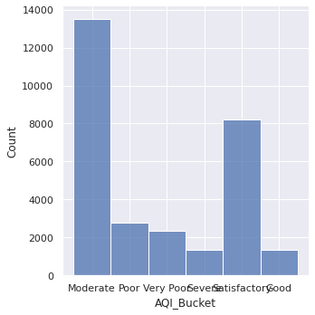

```python
#distribution of AQI_Bucket
import seaborn as sns
sns.displot(data=df_city_day,x='AQI_Bucket')
```

- Our data is imbalanced.
- The most frequent AQI labels are "Moderate" and "Satisfactory".

**Let's have a look on distribution of AQI_Bucket with city.**

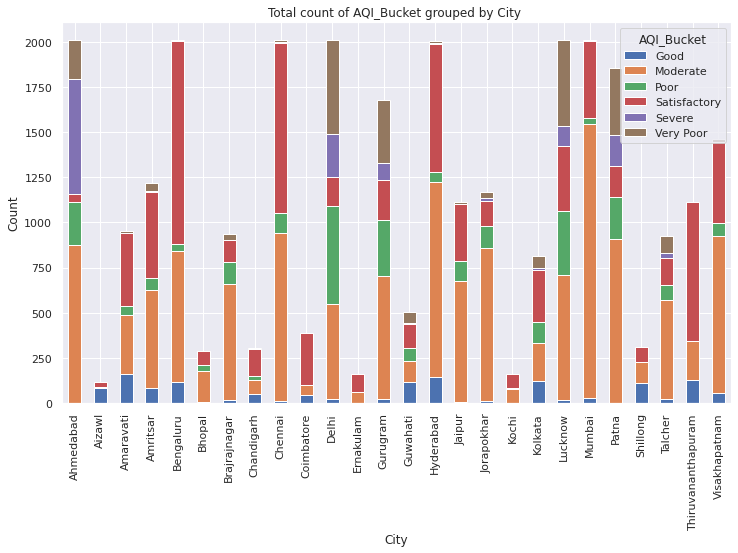

```python
# Distribution of AQI_Bucket with respect to City
df_city_day.groupby(['City', 'AQI_Bucket']).size().unstack().plot(kind='bar', stacked=True,figsize=(12,7))
plt.title(f"Total count of AQI_Bucket grouped by {'City'} ")
plt.ylabel('Count')
plt.show()
```

**Note:**- This data only represents the count of data present for each city in the dataset.

For most of the cities, the moderate AQI has the highest frequency compared to other AQI labels in AQI_Bucket.

**Comparing average AQI for each city.**

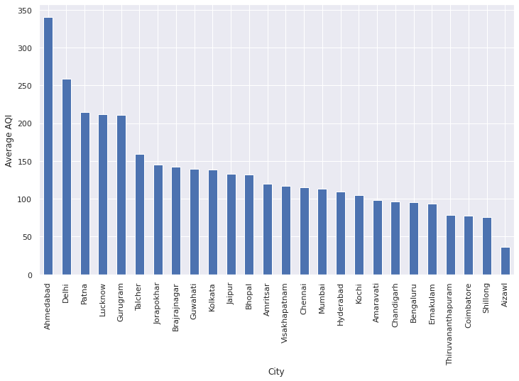

```python
# Comparing average AQI for each city
df_city_day.groupby('City')['AQI'].mean().sort_values(ascending=False).plot(kind='bar',figsize=(12,7))
plt.ylabel('Average AQI')
plt.show()
```

- **AQI of Ahmedabad is worst(beyond 300), which can be classified as "Very Poor".**
- **Other cities having Average AQI beyond 200 are- Delhi, Gurugram, Lucknow and Patna. These cities can be classified as a city having Poor Air quality.**

**Now let's look on the concentration of pollutants contributing to AQI for each city.**

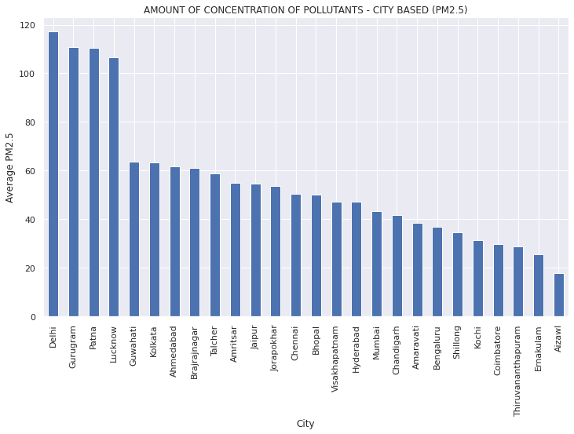

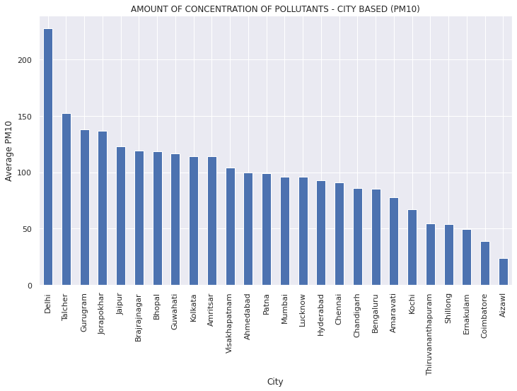

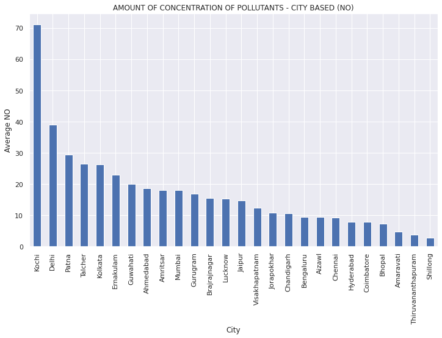

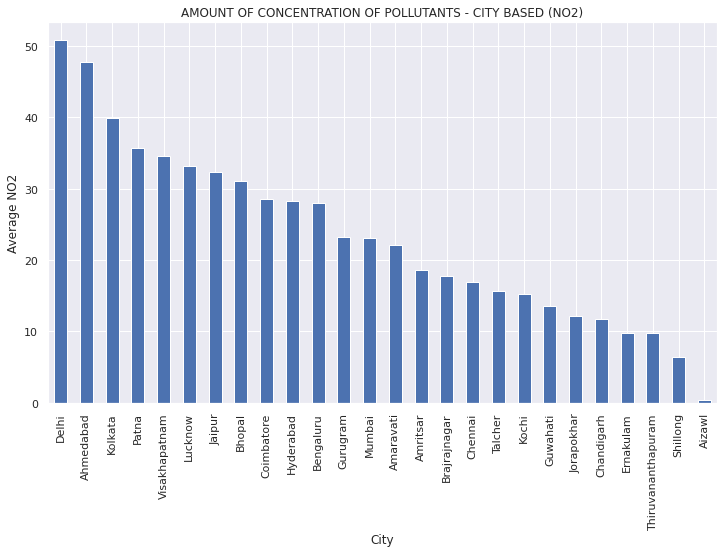

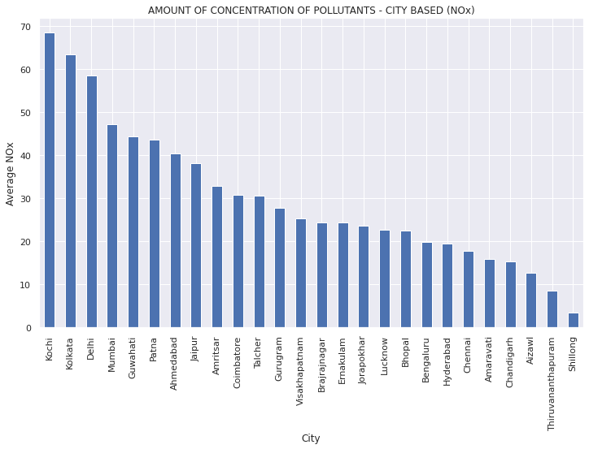

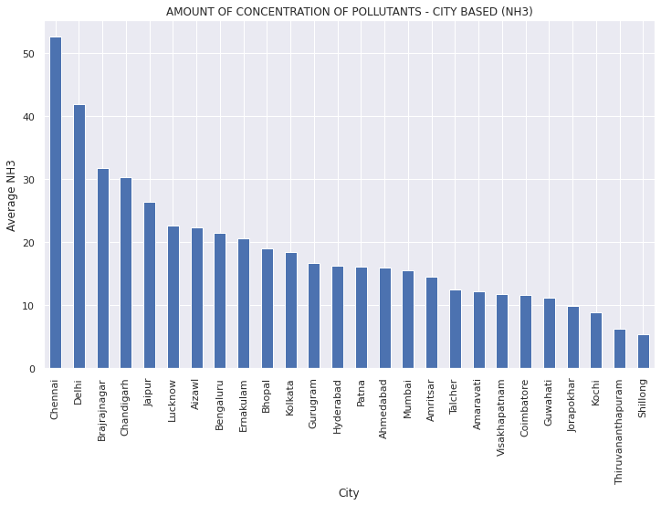

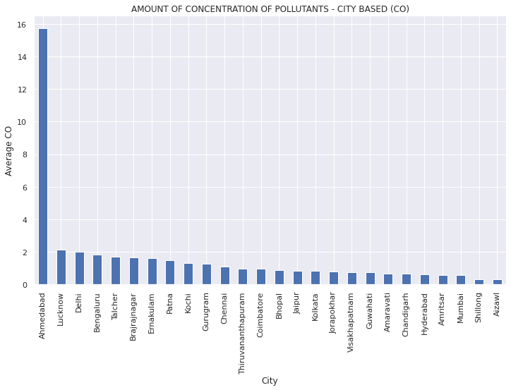

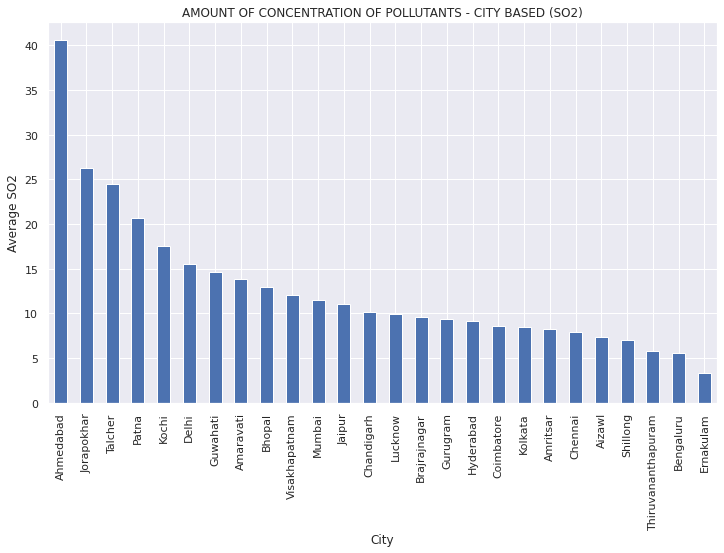

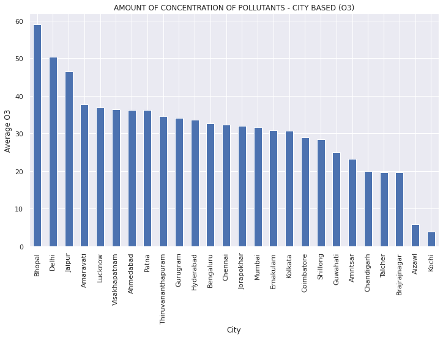

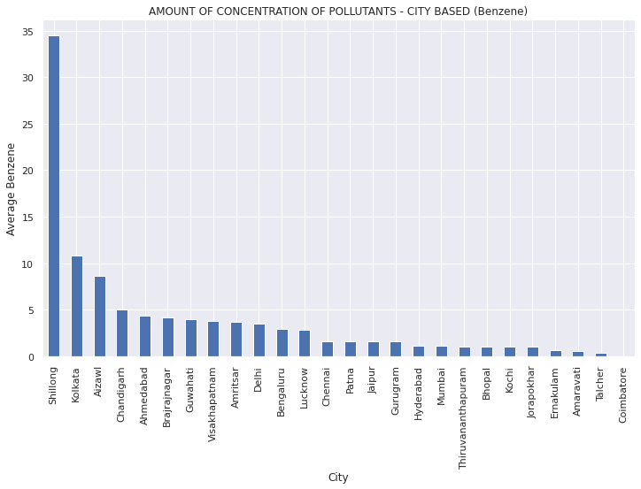

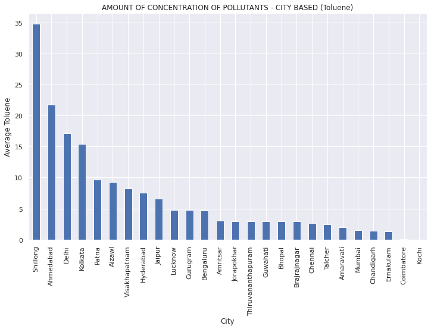

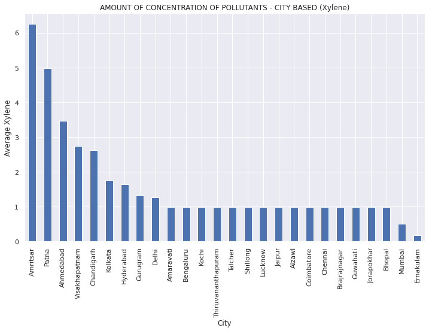

```python
#Concentration of pollutant for each city
pollutant_list = ['PM2.5',	'PM10',	'NO',	'NO2',	'NOx',	'NH3',	'CO',	'SO2',	'O3',	'Benzene',	'Toluene',	'Xylene']
for col in pollutant_list:
  df_city_day.groupby('City')[col].mean().sort_values(ascending=False).plot(kind='bar',figsize=(12,7))
  plt.ylabel(f'Average {col}',fontsize=12)
  plt.xlabel('City',fontsize=12)
  plt.title(f"AMOUNT OF CONCENTRATION OF POLLUTANTS - CITY BASED ({col})")
  plt.show()
```

**Exploring the trend of AQI over the years for all cities.**

```python
df_city_day['Date'].min()
```

```
Timestamp('2015-01-01 00:00:00')
```

```python
df_city_day['Date'].max()
```

```
Timestamp('2020-07-01 00:00:00')
```

**Our data is from 01-01-2015 to 01-07-2020**

```python
pd.DatetimeIndex(df_city_day['Date']).year.value_counts()
```

```
2019    7446
2018    6471
2017    4689
2020    4646
2016    3478
2015    2801
Name: Date, dtype: int64
```

```python
# Creting a 'Year' column
df_city_day['Year'] = pd.DatetimeIndex(df_city_day['Date']).year
```

```python
df_city_day.head()
```

|  | City | Date | PM2.5 | PM10 | NO | NO2 | NOx | NH3 | CO | SO2 | O3 | Benzene | Toluene | Xylene | AQI | AQI_Bucket | Year |
| --- | --- | --- | --- | --- | --- | --- | --- | --- | --- | --- | --- | --- | --- | --- | --- | --- | --- |
| 0 | Ahmedabad | 2015-01-01 | 48.57 | 95.68 | 0.92 | 18.22 | 17.15 | 15.85 | 0.92 | 27.64 | 133.36 | 0.00 | 0.02 | 0.00 | 118.0 | Moderate | 2015 |
| 1 | Ahmedabad | 2015-01-02 | 48.57 | 95.68 | 0.97 | 15.69 | 16.46 | 15.85 | 0.97 | 24.55 | 34.06 | 3.68 | 5.50 | 3.77 | 118.0 | Moderate | 2015 |
| 2 | Ahmedabad | 2015-01-03 | 48.57 | 95.68 | 17.40 | 19.30 | 29.70 | 15.85 | 17.40 | 29.07 | 30.70 | 6.80 | 16.40 | 2.25 | 118.0 | Moderate | 2015 |
| 3 | Ahmedabad | 2015-01-04 | 48.57 | 95.68 | 1.70 | 18.48 | 17.97 | 15.85 | 1.70 | 18.59 | 36.08 | 4.43 | 10.14 | 1.00 | 118.0 | Moderate | 2015 |
| 4 | Ahmedabad | 2015-01-05 | 48.57 | 95.68 | 22.10 | 21.42 | 37.76 | 15.85 | 22.10 | 39.33 | 39.31 | 7.01 | 18.89 | 2.78 | 118.0 | Moderate | 2015 |

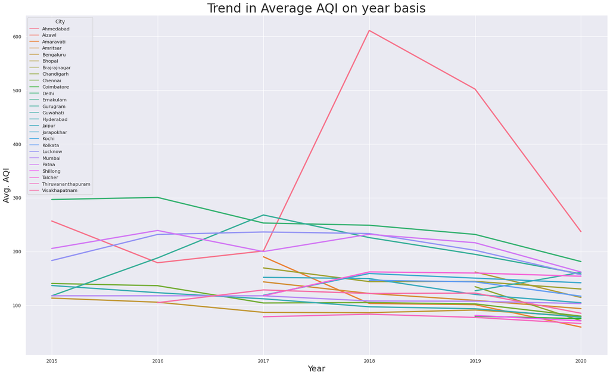

```python
# Geberating the plot
sns.lineplot(data=df_city_day,x='Year',y='AQI',hue='City',err_style=None,linewidth=3)
sns.set(rc={'figure.figsize':(25,15)})
plt.title('Trend in Average AQI on year basis',fontsize=30)
plt.xlabel('Year',fontsize=20)
plt.ylabel('Avg. AQI',fontsize=20)
plt.show()
```

- From 2017 to 2018 there is a rapid increase in the AQI for the city Ahmedabad, which is exception to trend followed by other cities.
- The most contributing pollutants for this high AQI for Ahmedabad are high CO, So2, No2, Toulene and Xylene.

**Let's see how the trend of AQI follows on hourly basis.**

```python
df_city_hour.head()
```

|  | City | Datetime | PM2.5 | PM10 | NO | NO2 | NOx | NH3 | CO | SO2 | O3 | Benzene | Toluene | Xylene | AQI | AQI_Bucket |
| --- | --- | --- | --- | --- | --- | --- | --- | --- | --- | --- | --- | --- | --- | --- | --- | --- |
| 0 | Ahmedabad | 2015-01-01 01:00:00 | NaN | NaN | 1.00 | 40.01 | 36.37 | NaN | 1.00 | 122.07 | NaN | 0.0 | 0.0 | 0.0 | NaN | NaN |
| 1 | Ahmedabad | 2015-01-01 02:00:00 | NaN | NaN | 0.02 | 27.75 | 19.73 | NaN | 0.02 | 85.90 | NaN | 0.0 | 0.0 | 0.0 | NaN | NaN |
| 2 | Ahmedabad | 2015-01-01 03:00:00 | NaN | NaN | 0.08 | 19.32 | 11.08 | NaN | 0.08 | 52.83 | NaN | 0.0 | 0.0 | 0.0 | NaN | NaN |
| 3 | Ahmedabad | 2015-01-01 04:00:00 | NaN | NaN | 0.30 | 16.45 | 9.20 | NaN | 0.30 | 39.53 | 153.58 | 0.0 | 0.0 | 0.0 | NaN | NaN |
| 4 | Ahmedabad | 2015-01-01 05:00:00 | NaN | NaN | 0.12 | 14.90 | 7.85 | NaN | 0.12 | 32.63 | NaN | 0.0 | 0.0 | 0.0 | NaN | NaN |

```python
df_city_hour.shape
```

```
(707875, 16)
```

```python
#checking Null Values
df_city_hour.isna().sum()
```

```
City               0
Datetime           0
PM2.5         145088
PM10          296737
NO            116632
NO2           117122
NOx           123224
NH3           272542
CO             86517
SO2           130373
O3            129208
Benzene       163646
Toluene       220607
Xylene        455829
AQI           129080
AQI_Bucket    129080
dtype: int64
```

```python
df_city_hour['AQI'].isna().sum()
```

```
129080
```

```python
# Replacing the Null values
df_city_hour['AQI'] = df_city_hour['AQI'].fillna(df_city_hour['AQI'].median())
```

```python
df_city_hour.info()
```

```
<class 'pandas.core.frame.DataFrame'>
RangeIndex: 707875 entries, 0 to 707874
Data columns (total 16 columns):
 #   Column      Non-Null Count   Dtype
---  ------      --------------   -----
 0   City        707875 non-null  object
 1   Datetime    707875 non-null  object
 2   PM2.5       562787 non-null  float64
 3   PM10        411138 non-null  float64
 4   NO          591243 non-null  float64
 5   NO2         590753 non-null  float64
 6   NOx         584651 non-null  float64
 7   NH3         435333 non-null  float64
 8   CO          621358 non-null  float64
 9   SO2         577502 non-null  float64
 10  O3          578667 non-null  float64
 11  Benzene     544229 non-null  float64
 12  Toluene     487268 non-null  float64
 13  Xylene      252046 non-null  float64
 14  AQI         707875 non-null  float64
 15  AQI_Bucket  578795 non-null  object
dtypes: float64(13), object(3)
memory usage: 86.4+ MB
```

```python
# Changing the format of 'Datetime' to datetime
df_city_hour['Datetime']=pd.to_datetime(df_city_hour['Datetime'])
```

```python
#creating new derived features
df_city_hour['time'] = pd.DatetimeIndex(df_city_hour['Datetime']).time
df_city_hour['Date'] = pd.DatetimeIndex(df_city_hour['Datetime']).date
```

```python
df_city_hour.head()
```

|  | City | Datetime | PM2.5 | PM10 | NO | NO2 | NOx | NH3 | CO | SO2 | O3 | Benzene | Toluene | Xylene | AQI | AQI_Bucket | time | Date |
| --- | --- | --- | --- | --- | --- | --- | --- | --- | --- | --- | --- | --- | --- | --- | --- | --- | --- | --- |
| 0 | Ahmedabad | 2015-01-01 01:00:00 | NaN | NaN | 1.00 | 40.01 | 36.37 | NaN | 1.00 | 122.07 | NaN | 0.0 | 0.0 | 0.0 | 116.0 | NaN | 01:00:00 | 2015-01-01 |
| 1 | Ahmedabad | 2015-01-01 02:00:00 | NaN | NaN | 0.02 | 27.75 | 19.73 | NaN | 0.02 | 85.90 | NaN | 0.0 | 0.0 | 0.0 | 116.0 | NaN | 02:00:00 | 2015-01-01 |
| 2 | Ahmedabad | 2015-01-01 03:00:00 | NaN | NaN | 0.08 | 19.32 | 11.08 | NaN | 0.08 | 52.83 | NaN | 0.0 | 0.0 | 0.0 | 116.0 | NaN | 03:00:00 | 2015-01-01 |
| 3 | Ahmedabad | 2015-01-01 04:00:00 | NaN | NaN | 0.30 | 16.45 | 9.20 | NaN | 0.30 | 39.53 | 153.58 | 0.0 | 0.0 | 0.0 | 116.0 | NaN | 04:00:00 | 2015-01-01 |
| 4 | Ahmedabad | 2015-01-01 05:00:00 | NaN | NaN | 0.12 | 14.90 | 7.85 | NaN | 0.12 | 32.63 | NaN | 0.0 | 0.0 | 0.0 | 116.0 | NaN | 05:00:00 | 2015-01-01 |

**Let's take particular random date and see the variation of AQI on hourly basis for each city.**

```python
# creating data for a random date
from datetime import datetime
df_01_05_2018  = df_city_hour[df_city_hour['Date']== (datetime.strptime('2018-05-01', '%Y-%m-%d').date())]
```

```python
df_01_05_2018.head()
```

|  | City | Datetime | PM2.5 | PM10 | NO | NO2 | NOx | NH3 | CO | SO2 | O3 | Benzene | Toluene | Xylene | AQI | AQI_Bucket | time | Date |
| --- | --- | --- | --- | --- | --- | --- | --- | --- | --- | --- | --- | --- | --- | --- | --- | --- | --- | --- |
| 29183 | Ahmedabad | 2018-05-01 00:00:00 | 68.99 | NaN | 20.86 | 35.38 | 32.83 | NaN | 20.86 | 165.09 | 9.28 | 19.92 | 38.45 | 0.65 | 334.0 | Very Poor | 00:00:00 | 2018-05-01 |
| 29184 | Ahmedabad | 2018-05-01 01:00:00 | 69.33 | NaN | 14.79 | 29.61 | 25.47 | NaN | 14.79 | 50.70 | 9.87 | 10.29 | 32.11 | 0.65 | 334.0 | Very Poor | 01:00:00 | 2018-05-01 |
| 29185 | Ahmedabad | 2018-05-01 02:00:00 | 79.79 | NaN | 11.36 | 26.82 | 21.56 | NaN | 11.36 | 47.07 | 5.11 | 5.60 | 27.53 | 0.65 | 334.0 | Very Poor | 02:00:00 | 2018-05-01 |
| 29186 | Ahmedabad | 2018-05-01 03:00:00 | 91.56 | NaN | 9.71 | 30.35 | 22.06 | NaN | 9.71 | 84.73 | 10.17 | 10.03 | 25.91 | 0.65 | 334.0 | Very Poor | 03:00:00 | 2018-05-01 |
| 29187 | Ahmedabad | 2018-05-01 04:00:00 | 67.18 | NaN | 19.34 | 31.32 | 29.71 | NaN | 19.34 | 131.93 | 9.10 | 11.11 | 28.51 | 0.65 | 334.0 | Very Poor | 04:00:00 | 2018-05-01 |

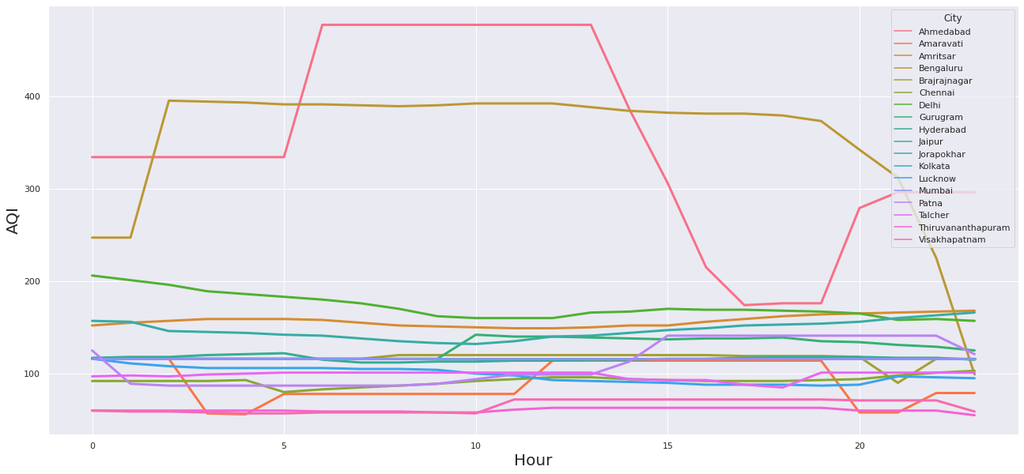

```python
# Creating the plot
sns.lineplot(data=df_01_05_2018,x=df_01_05_2018['Datetime'].dt.hour,y='AQI',hue='City',err_style=None,linewidth=3)
sns.set(rc={'figure.figsize':(22,10)})
plt.xlabel('Hour',fontsize=20)
plt.ylabel('AQI',fontsize=20)
plt.show()
```

For most of the city the trend followed by 'AQI' hourly is nearly constant except some cities.

It will be interesting to see the AQI level on particular days like- new year or diwali , where the chances of pollution increase is at peak.

**New Year analysis**

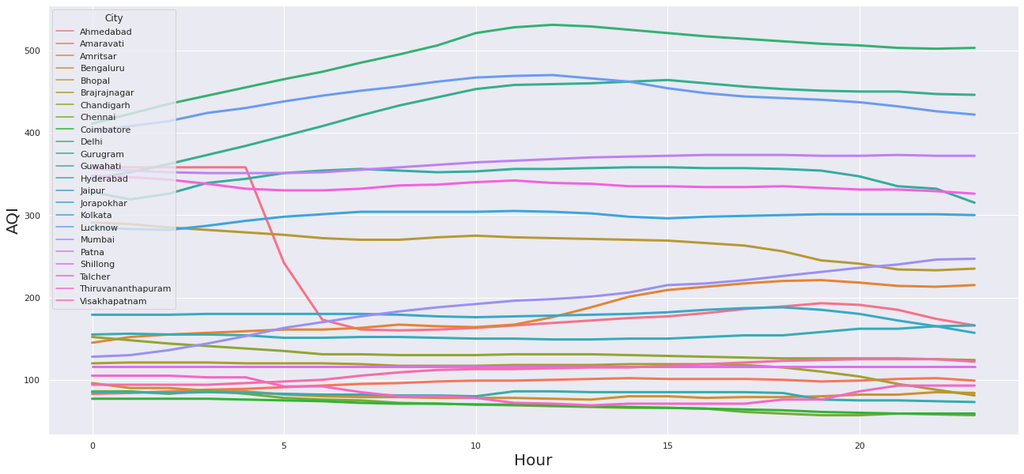

```python
#creating the plot for new year data
from datetime import datetime
df_01_01_2020  = df_city_hour[df_city_hour['Date']== (datetime.strptime('2020-01-01', '%Y-%m-%d').date())]
sns.lineplot(data=df_01_01_2020,x=df_01_01_2020['Datetime'].dt.hour,y='AQI',hue='City',err_style=None,linewidth=3)
sns.set(rc={'figure.figsize':(22,10)})
plt.xlabel('Hour',fontsize=20)
plt.ylabel('AQI',fontsize=20)
plt.show()
```

**Diwali Analysis**

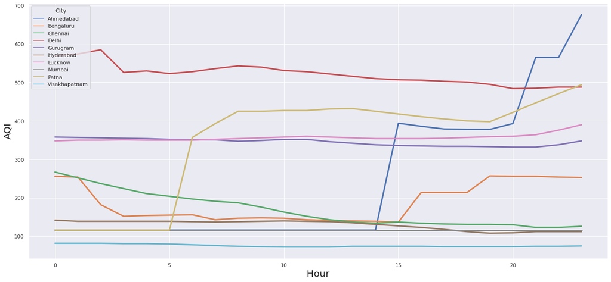

```python
#creating the plot for diwali data
from datetime import datetime
df_30_10_2016  = df_city_hour[df_city_hour['Date']== (datetime.strptime('2016-10-30', '%Y-%m-%d').date())]
sns.lineplot(data=df_30_10_2016,x=df_30_10_2016['Datetime'].dt.hour,y='AQI',hue='City',err_style=None,linewidth=3)
sns.set(rc={'figure.figsize':(22,10)})
plt.xlabel('Hour',fontsize=20)
plt.ylabel('AQI',fontsize=20)
plt.show()
```

**It can be easily oberserved the above two graphs that how the festivals of crackers can rapidly increase the AQI.**

```python
df_city_day.head()
```

|  | City | Date | PM2.5 | PM10 | NO | NO2 | NOx | NH3 | CO | SO2 | O3 | Benzene | Toluene | Xylene | AQI | AQI_Bucket | Year |
| --- | --- | --- | --- | --- | --- | --- | --- | --- | --- | --- | --- | --- | --- | --- | --- | --- | --- |
| 0 | Ahmedabad | 2015-01-01 | 48.57 | 95.68 | 0.92 | 18.22 | 17.15 | 15.85 | 0.92 | 27.64 | 133.36 | 0.00 | 0.02 | 0.00 | 118.0 | Moderate | 2015 |
| 1 | Ahmedabad | 2015-01-02 | 48.57 | 95.68 | 0.97 | 15.69 | 16.46 | 15.85 | 0.97 | 24.55 | 34.06 | 3.68 | 5.50 | 3.77 | 118.0 | Moderate | 2015 |
| 2 | Ahmedabad | 2015-01-03 | 48.57 | 95.68 | 17.40 | 19.30 | 29.70 | 15.85 | 17.40 | 29.07 | 30.70 | 6.80 | 16.40 | 2.25 | 118.0 | Moderate | 2015 |
| 3 | Ahmedabad | 2015-01-04 | 48.57 | 95.68 | 1.70 | 18.48 | 17.97 | 15.85 | 1.70 | 18.59 | 36.08 | 4.43 | 10.14 | 1.00 | 118.0 | Moderate | 2015 |
| 4 | Ahmedabad | 2015-01-05 | 48.57 | 95.68 | 22.10 | 21.42 | 37.76 | 15.85 | 22.10 | 39.33 | 39.31 | 7.01 | 18.89 | 2.78 | 118.0 | Moderate | 2015 |

**Now in order to take control over these pollutants, we need to understand sources of these pollutants.**

In order to simplify, we will consider two catagories of pollutants -

1. **Industrial Pollutants**(SO2,O3,Benzene,Toluene,Xylene)
2. **Vehicle Pollutants**(PM2.5,PM10,NO,NO2,NOx,NH3,CO)

```python
#creating new derived features
Pollutants_df = df_city_day.copy()
Pollutants_df['Industrial_pollutants'] = Pollutants_df['SO2']+Pollutants_df['O3']+Pollutants_df['Benzene']+Pollutants_df['Toluene']+Pollutants_df['Xylene']
Pollutants_df['Vehical_pollutants'] = Pollutants_df['PM2.5']+Pollutants_df['PM10']+Pollutants_df['NO']+Pollutants_df['NO2']+Pollutants_df['NOx']+Pollutants_df['NH3']+Pollutants_df['CO']
Pollutants_df.drop(columns=['PM2.5','PM10','NO','NO2','NOx','NH3','CO','SO2','O3','Benzene','Toluene','Xylene'],axis=1,inplace=True)
```

```python
Pollutants_df.head()
```

|  | City | Date | AQI | AQI_Bucket | Year | Industrial_pollutants | Vehical_pollutants |
| --- | --- | --- | --- | --- | --- | --- | --- |
| 0 | Ahmedabad | 2015-01-01 | 118.0 | Moderate | 2015 | 161.02 | 197.31 |
| 1 | Ahmedabad | 2015-01-02 | 118.0 | Moderate | 2015 | 71.56 | 194.19 |
| 2 | Ahmedabad | 2015-01-03 | 118.0 | Moderate | 2015 | 85.22 | 243.90 |
| 3 | Ahmedabad | 2015-01-04 | 118.0 | Moderate | 2015 | 70.24 | 199.95 |
| 4 | Ahmedabad | 2015-01-05 | 118.0 | Moderate | 2015 | 107.32 | 263.48 |

```python
#creating new dataframe
Pollutants_df_new = Pollutants_df.groupby('City')[['Industrial_pollutants','Vehical_pollutants']].mean()
```

```python
Pollutants_df_new.head()
```

| City | Industrial_pollutants | Vehical_pollutants |
| --- | --- | --- |
| Ahmedabad | 106.505620 | 299.591354 |
| Aizawl | 32.157257 | 86.678850 |
| Amaravati | 55.136877 | 171.539064 |
| Amritsar | 44.451360 | 253.407789 |
| Bengaluru | 46.840806 | 202.521229 |

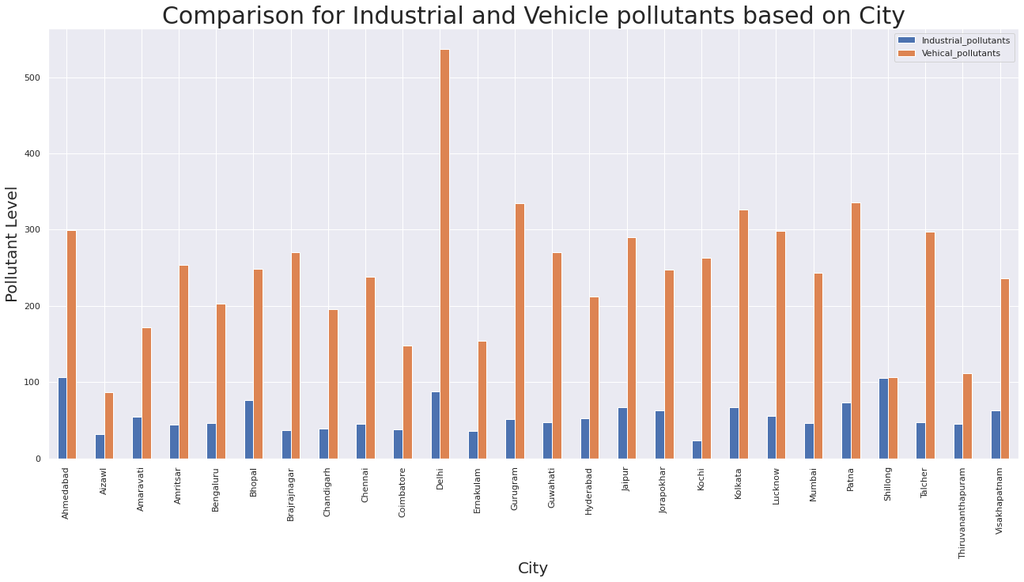

```python
#creating the plot
Pollutants_df_new.plot.bar()
plt.title('Comparison for Industrial and Vehicle pollutants based on City',fontsize=30)
plt.xlabel('City',fontsize=20)
plt.ylabel('Pollutant Level',fontsize=20)
plt.show()
```

- **It can be observed that the vehicle pollutants are the one having major contribution towards the pollution in all cities.**
- **Delhi being on top for vehicle pollution while Ahmedabad on top for Industrial pollution.**

Since our dataset contains the data during the lockdown, it will quite interesting to visualize the pollution graph before and after lockdown for each city.

```python
Pollutants_df.head()
```

|  | City | Date | AQI | AQI_Bucket | Year | Industrial_pollutants | Vehical_pollutants |
| --- | --- | --- | --- | --- | --- | --- | --- |
| 0 | Ahmedabad | 2015-01-01 | 118.0 | Moderate | 2015 | 161.02 | 197.31 |
| 1 | Ahmedabad | 2015-01-02 | 118.0 | Moderate | 2015 | 71.56 | 194.19 |
| 2 | Ahmedabad | 2015-01-03 | 118.0 | Moderate | 2015 | 85.22 | 243.90 |
| 3 | Ahmedabad | 2015-01-04 | 118.0 | Moderate | 2015 | 70.24 | 199.95 |
| 4 | Ahmedabad | 2015-01-05 | 118.0 | Moderate | 2015 | 107.32 | 263.48 |

```python
#range of data
print(Pollutants_df['Date'].min())
print(Pollutants_df['Date'].max())
```

```
2015-01-01 00:00:00
2020-07-01 00:00:00
```

```python
#creating precovid dataset
precovid_df = Pollutants_df[Pollutants_df['Date']<='2020-03-24']
```

```python
precovid_df.shape
```

```
(26957, 7)
```

```python
#creating postcovid dataset
postcovid_df = Pollutants_df[Pollutants_df['Date']>'2020-03-24']
postcovid_df.shape
```

```
(2574, 7)
```

```python
# filtering the data to create new one
precovid_df_new = precovid_df.groupby('City')[['Industrial_pollutants','Vehical_pollutants']].mean()
```

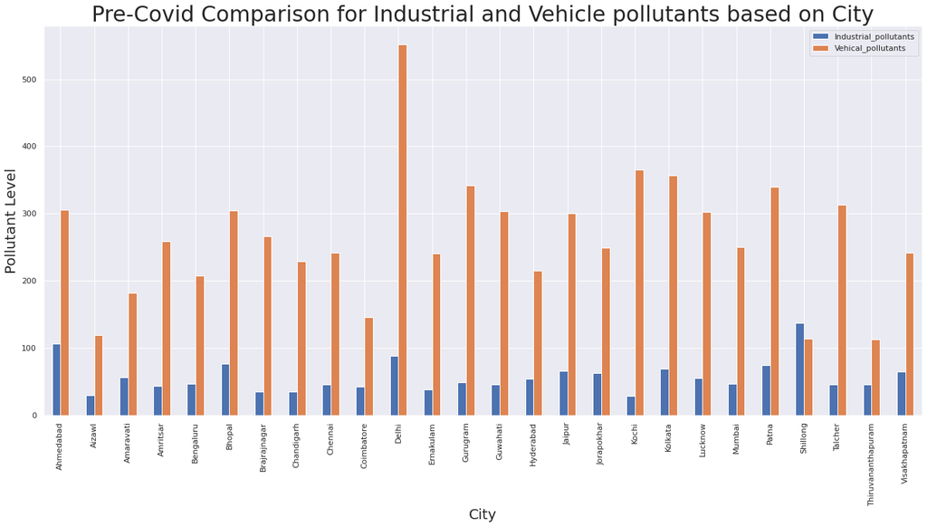

```python
#creating the plot
precovid_df_new.plot.bar()
plt.title('Pre-Covid Comparison for Industrial and Vehicle pollutants based on City',fontsize=30)
plt.xlabel('City',fontsize=20)
plt.ylabel('Pollutant Level',fontsize=20)
plt.show()
```

```python
# filtering the data to create new one
postcovid_df_new = postcovid_df.groupby('City')[['Industrial_pollutants','Vehical_pollutants']].mean()
```

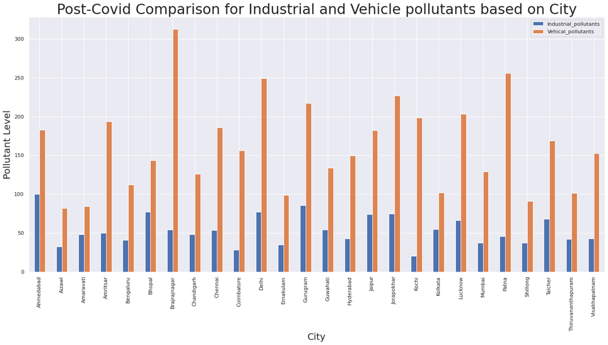

```python
#creating the plot
postcovid_df_new.plot.bar()
plt.title('Post-Covid Comparison for Industrial and Vehicle pollutants based on City',fontsize=30)
plt.xlabel('City',fontsize=20)
plt.ylabel('Pollutant Level',fontsize=20)
plt.show()
```

**It is interesting to see how post-covid scenerio has bring down the vehicle pollutants to a significant level due to lockdown.**

- The most significant drop is observed for Delhi.
- Brajrajnagar is showing exception, where the vehicle pollutant level increased after covid.

## **Correlation**

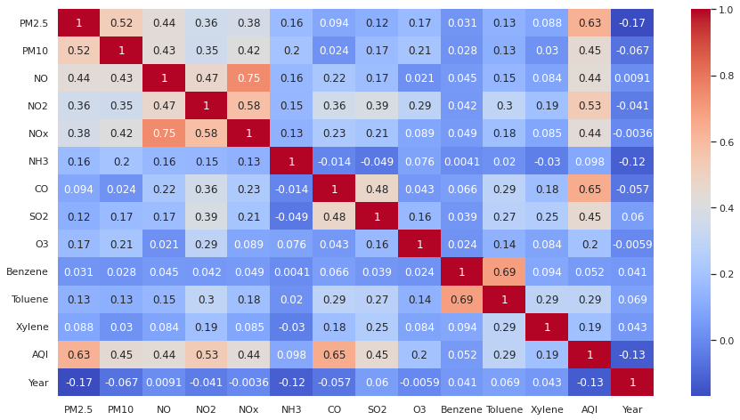

```python
## Correlation between variables
plt.figure(figsize=(15,8))
correlation = df_city_day.corr()
sns.heatmap((correlation), annot=True, cmap='coolwarm')
```

# **Data Preparation**

```python
#creating copy of data
model_data = df_city_day.copy()
model_data.head()
```

|  | City | Date | PM2.5 | PM10 | NO | NO2 | NOx | NH3 | CO | SO2 | O3 | Benzene | Toluene | Xylene | AQI | AQI_Bucket | Year |
| --- | --- | --- | --- | --- | --- | --- | --- | --- | --- | --- | --- | --- | --- | --- | --- | --- | --- |
| 0 | Ahmedabad | 2015-01-01 | 48.57 | 95.68 | 0.92 | 18.22 | 17.15 | 15.85 | 0.92 | 27.64 | 133.36 | 0.00 | 0.02 | 0.00 | 118.0 | Moderate | 2015 |
| 1 | Ahmedabad | 2015-01-02 | 48.57 | 95.68 | 0.97 | 15.69 | 16.46 | 15.85 | 0.97 | 24.55 | 34.06 | 3.68 | 5.50 | 3.77 | 118.0 | Moderate | 2015 |
| 2 | Ahmedabad | 2015-01-03 | 48.57 | 95.68 | 17.40 | 19.30 | 29.70 | 15.85 | 17.40 | 29.07 | 30.70 | 6.80 | 16.40 | 2.25 | 118.0 | Moderate | 2015 |
| 3 | Ahmedabad | 2015-01-04 | 48.57 | 95.68 | 1.70 | 18.48 | 17.97 | 15.85 | 1.70 | 18.59 | 36.08 | 4.43 | 10.14 | 1.00 | 118.0 | Moderate | 2015 |
| 4 | Ahmedabad | 2015-01-05 | 48.57 | 95.68 | 22.10 | 21.42 | 37.76 | 15.85 | 22.10 | 39.33 | 39.31 | 7.01 | 18.89 | 2.78 | 118.0 | Moderate | 2015 |

Since AQI_Bucket is a derived feature from AQI and AQI is our target variable for prediction, we will be dropping the AQI_Bucket column.

Year is a feature we have derived from Date, so we will also drop the Date column.

```python
# dropping the date column
model_data.drop(columns=['Date','AQI_Bucket'],axis=1,inplace=True)
```

```python
#One hot encoding for nominal variables
model_data = pd.get_dummies(model_data, columns=["City","Year"])
```

```python
#standardize continuous features
from scipy.stats import zscore
model_data[['PM2.5','PM10','NO','NO2','NOx','NH3','CO','SO2','O3','Benzene','Toluene','Xylene']]=model_data[['PM2.5','PM10','NO','NO2','NOx','NH3','CO','SO2','O3','Benzene','Toluene','Xylene']].apply(zscore)
```

```python
model_data.head()
```

|  | PM2.5 | PM10 | NO | NO2 | NOx | NH3 | CO | SO2 | O3 | Benzene | ... | City_Shillong | City_Talcher | City_Thiruvananthapuram | City_Visakhapatnam | Year_2015 | Year_2016 | Year_2017 | Year_2018 | Year_2019 | Year_2020 |
| --- | --- | --- | --- | --- | --- | --- | --- | --- | --- | --- | --- | --- | --- | --- | --- | --- | --- | --- | --- | --- | --- |
| 0 | -0.26654 | -0.193291 | -0.731090 | -0.412430 | -0.472010 | -0.23605 | -0.183488 | 0.812044 | 4.918625 | -0.200657 | ... | 0 | 0 | 0 | 0 | 1 | 0 | 0 | 0 | 0 | 0 |
| 1 | -0.26654 | -0.193291 | -0.728765 | -0.522191 | -0.495418 | -0.23605 | -0.176052 | 0.630337 | 0.003261 | 0.057542 | ... | 0 | 0 | 0 | 0 | 1 | 0 | 0 | 0 | 0 | 0 |
| 2 | -0.26654 | -0.193291 | 0.035219 | -0.365576 | -0.046258 | -0.23605 | 2.267235 | 0.896135 | -0.163059 | 0.276450 | ... | 0 | 0 | 0 | 0 | 1 | 0 | 0 | 0 | 0 | 0 |
| 3 | -0.26654 | -0.193291 | -0.694820 | -0.401151 | -0.444192 | -0.23605 | -0.067495 | 0.279859 | 0.103251 | 0.110164 | ... | 0 | 0 | 0 | 0 | 1 | 0 | 0 | 0 | 0 | 0 |
| 4 | -0.26654 | -0.193291 | 0.253765 | -0.273602 | 0.227173 | -0.23605 | 2.966167 | 1.499475 | 0.263137 | 0.291184 | ... | 0 | 0 | 0 | 0 | 1 | 0 | 0 | 0 | 0 | 0 |

5 rows × 45 columns

```python
#checking columns
model_data.columns
```

```
Index(['PM2.5', 'PM10', 'NO', 'NO2', 'NOx', 'NH3', 'CO', 'SO2', 'O3',
       'Benzene', 'Toluene', 'Xylene', 'AQI', 'City_Ahmedabad', 'City_Aizawl',
       'City_Amaravati', 'City_Amritsar', 'City_Bengaluru', 'City_Bhopal',
       'City_Brajrajnagar', 'City_Chandigarh', 'City_Chennai',
       'City_Coimbatore', 'City_Delhi', 'City_Ernakulam', 'City_Gurugram',
       'City_Guwahati', 'City_Hyderabad', 'City_Jaipur', 'City_Jorapokhar',
       'City_Kochi', 'City_Kolkata', 'City_Lucknow', 'City_Mumbai',
       'City_Patna', 'City_Shillong', 'City_Talcher',
       'City_Thiruvananthapuram', 'City_Visakhapatnam', 'Year_2015',
       'Year_2016', 'Year_2017', 'Year_2018', 'Year_2019', 'Year_2020'],
      dtype='object')
```

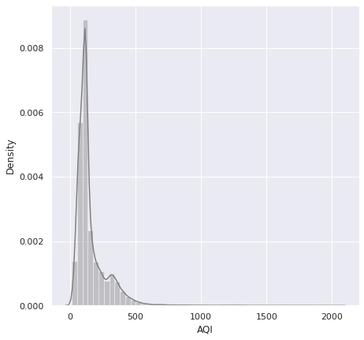

```python
#distribution of target variable 'AQI'
import seaborn as sns
plt.figure(figsize=(7,7))
sns.distplot(model_data['AQI'],color="grey")
```

```python
# skew of the dependent variable
model_data['AQI'].skew()
```

```
3.76975148929373
```

Our target variable is positively skewed, we will try to normalize it using transformations.

```python
# checking skewness using different transformations
print(np.log10(model_data['AQI']).skew())
print(np.sqrt(model_data['AQI']).skew())
print(1/(model_data['AQI']).skew())
```

```
0.47424329972347706
1.6788266180736655
0.2652694754123837
```

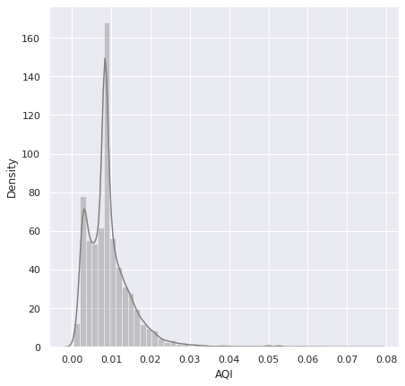

```python
#Log transformation on target variable
plt.figure(figsize=(7,7))
sns.distplot(1/(model_data['AQI']),color="grey")
```

```python
# Repositioning the dependent variable to last index
last_column = model_data.pop('AQI')
model_data.insert(44, 'AQI', last_column)
model_data.head()
```

|  | PM2.5 | PM10 | NO | NO2 | NOx | NH3 | CO | SO2 | O3 | Benzene | ... | City_Talcher | City_Thiruvananthapuram | City_Visakhapatnam | Year_2015 | Year_2016 | Year_2017 | Year_2018 | Year_2019 | Year_2020 | AQI |
| --- | --- | --- | --- | --- | --- | --- | --- | --- | --- | --- | --- | --- | --- | --- | --- | --- | --- | --- | --- | --- | --- |
| 0 | -0.26654 | -0.193291 | -0.731090 | -0.412430 | -0.472010 | -0.23605 | -0.183488 | 0.812044 | 4.918625 | -0.200657 | ... | 0 | 0 | 0 | 1 | 0 | 0 | 0 | 0 | 0 | 118.0 |
| 1 | -0.26654 | -0.193291 | -0.728765 | -0.522191 | -0.495418 | -0.23605 | -0.176052 | 0.630337 | 0.003261 | 0.057542 | ... | 0 | 0 | 0 | 1 | 0 | 0 | 0 | 0 | 0 | 118.0 |
| 2 | -0.26654 | -0.193291 | 0.035219 | -0.365576 | -0.046258 | -0.23605 | 2.267235 | 0.896135 | -0.163059 | 0.276450 | ... | 0 | 0 | 0 | 1 | 0 | 0 | 0 | 0 | 0 | 118.0 |
| 3 | -0.26654 | -0.193291 | -0.694820 | -0.401151 | -0.444192 | -0.23605 | -0.067495 | 0.279859 | 0.103251 | 0.110164 | ... | 0 | 0 | 0 | 1 | 0 | 0 | 0 | 0 | 0 | 118.0 |
| 4 | -0.26654 | -0.193291 | 0.253765 | -0.273602 | 0.227173 | -0.23605 | 2.966167 | 1.499475 | 0.263137 | 0.291184 | ... | 0 | 0 | 0 | 1 | 0 | 0 | 0 | 0 | 0 | 118.0 |

5 rows × 45 columns

**dependent and independent variable split**

```python
#spliting the data
X= model_data.iloc[:,:-1]
y= 1/model_data['AQI']
```

**Our data is ready for model**

# **Model Selection**

Here our task is to predict the AQI based on the pollutant data available. This task can be done using a regression model. Now the question is which regression model should we use?

And the answer for this question depends on the business requirement. Since we know that as we increase the accuracy of prediction using complex models, the explainability of the model reduces, which might create an issue for the stakeholders.

Considering the above situations we can have three choices-

- Simple model with low accuracy but high explainability
- Complex model with high accuracy but low explainability
- A compromised model between the above two cases

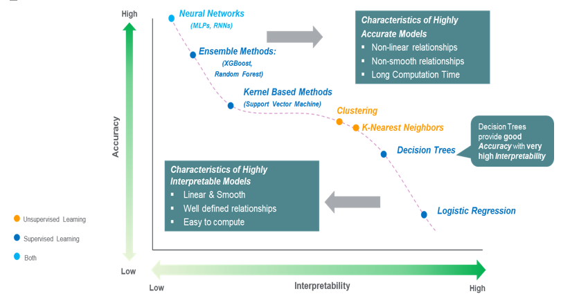

The above picture best explains the relationship between accuracy and interpretability of model

Now let us try to implement the regression model and observe the results.

# **Prediction**

```python
#creating function to predict on different models
from sklearn.model_selection import train_test_split
from sklearn.preprocessing import StandardScaler
from sklearn.metrics import r2_score
from sklearn.metrics import mean_squared_error
def predict(ml_model,X,y):
    X_train,X_test,y_train,y_test=train_test_split(X,y,test_size=0.25,random_state=12)
    sc=StandardScaler()
    X_train=sc.fit_transform(X_train)
    X_test=sc.transform(X_test)
    model=ml_model.fit(X_train,y_train)
    y_pred=model.predict(X_test)
    plt.scatter(y_pred,y_test,color='b')
    plt.xlabel('Predicted')
    plt.ylabel('Actual')
    # Evaluation metrics
    evaluation_metric=(f'R^2 is {r2_score(10**(y_test), 10**(y_pred))}\n Adj R^2 is {1-(1-r2_score(10**(y_test), 10**(y_pred)))*((X_test.shape[0]-1)/(X_test.shape[0]-X_test.shape[1]-1))}\n RMSE is: {np.sqrt(mean_squared_error(10**(y_test), 10**(y_pred)))}')
    print(evaluation_metric)
```

```python
sns.set(rc={'figure.figsize':(10,7)})
```

### **1. Linear Regression**

```
R^2 is 0.5726908625283431
 Adj R^2 is 0.5701286382098976
 RMSE is: 0.008903557809373604
```

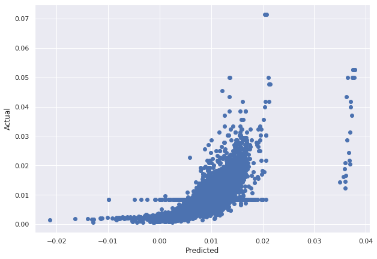

```python
from sklearn.linear_model import LinearRegression
predict(LinearRegression(),X,y)
```

### **2. Polynomial Regression**

```
R^2 is 0.743483575722633
 Adj R^2 is 0.7016536562130892
 RMSE is: 0.006898427139500642
```

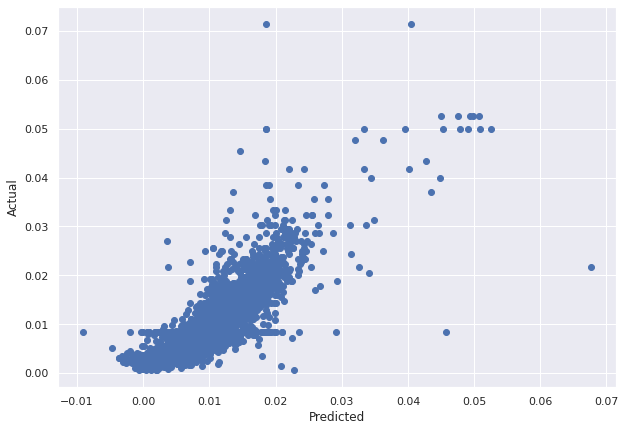

```python
from sklearn.preprocessing import PolynomialFeatures
poly_regs= PolynomialFeatures(degree= 2)
x_poly= poly_regs.fit_transform(X)
predict(LinearRegression(),x_poly,y)
```

### **3. DecisionTreeRegressor**

```
R^2 is 0.7054506443113386
 Adj R^2 is 0.7036844721049744
 RMSE is: 0.0073921629460735215
```

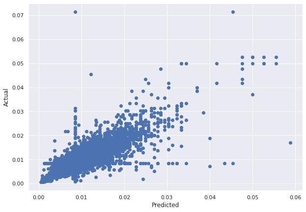

```python
from sklearn.tree import DecisionTreeRegressor
predict(DecisionTreeRegressor(),X,y)
```

### **4. RandomForestRegressor**

```
R^2 is 0.8389185643969684
 Adj R^2 is 0.8379526904304199
 RMSE is: 0.005466574091614321
```

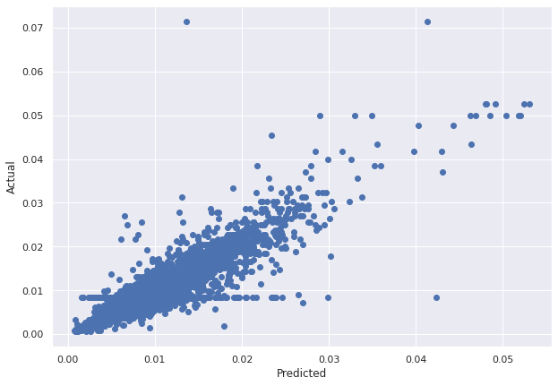

```python
from sklearn.ensemble import RandomForestRegressor
predict(RandomForestRegressor(),X,y)
```

### **5. XGBoost Regressor**

```
[06:42:58] WARNING: /workspace/src/objective/regression_obj.cu:152: reg:linear is now deprecated in favor of reg:squarederror.
R^2 is 0.7877963601665636
 Adj R^2 is 0.786523948044368
 RMSE is: 0.006274352402128863
```

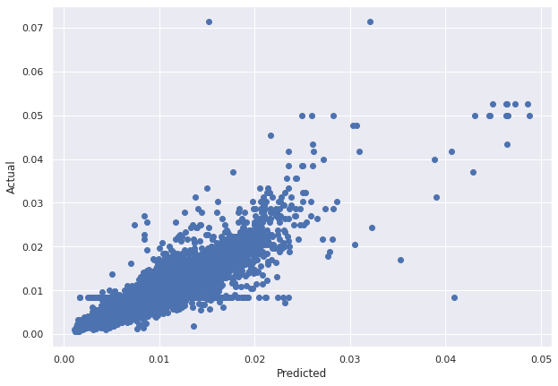

```python
import xgboost as xgb
predict(xgb.XGBRegressor(),X,y)
```

## **Conclusion**

We can clearly observe that Random forest Regressor is best fit for our data having the best R2 score and least Root Mean Squared Error (RMSE)